# Appendix

## Appendix 1: Estimating $\alpha$ with R

### Point estimation

Most implementations of the calculation of $\alpha$ are limited to solving the equation

$$S(n) = \alpha \ln \left( 1 + \frac{n}{\alpha} \right),$$

where $S(n)$ is the number of species observed in a sample of size $n$. The only data required are the total number of species and the sample size. The fifty hectares of BCI are used in the examples below.

```r
library("tidyverse")
library("vegan")
data(BCI)
BCI %>%
  colSums() ->
  BCI_50ha
```

Functions are:

- `vegan::fisher.alpha()` that relies on `vegan::fisherfit()`. The numerical resolution uses `uniroot()`.

```r
library("vegan")
fisher.alpha(BCI_50ha)
```

```
[1] 35.05477
```

```r
fisherfit(BCI_50ha)
```

```
Fisher log series model
No. of species: 225
Fisher alpha:   35.05477
```

- `untb::fishers.alpha()`, identical to `vegan::fisherfit()`

```r
library("untb")
fishers.alpha(N = sum(BCI_50ha), S = sum(BCI_50ha > 0))
```

```
[1] 35.05477
```

### Likelihood maximisation

The alternative is to adjust the observed abundance distribution to the theoretical distribution of a log series, maximising its likelihood as a function of $\alpha$.

This is done by `sads::fitls()` which uses `mle2()` to maximise the likelihood of `sads::dls()` (the probability density of the logs-eries). The default starting value is the point estimate.

```r
library("sads")
fitls(BCI_50ha)
```

```
Maximum likelihood estimation
Type: discrete  species abundance distribution
Species: 225 individuals: 21457

Call:
mle2(minuslogl = function (N, alpha)
-sum(dls(x, N, alpha, log = TRUE)), start = list(alpha = 35.0547728854782),
    method = "Brent", fixed = list(N = 21457), data = list(x = list(
        1, 3, 2, 1, 92, "etc")), lower = 0, upper = 225L)

Coefficients:
          N       alpha
21457.00000    35.05477

Log-likelihood: -1160.45
```

In the case of BCI, the result is the same: the likelihood calculation gives predominant weight to the most abundant species.

## Appendix 2: Estimating $\theta$ by the abundant species distribution

Hubbell (2001, 293) proposes estimating $\theta$ by adjusting the rank-abundance curve to the most frequent species in the community, arguing that these species are also the most abundant in the metacommunity.

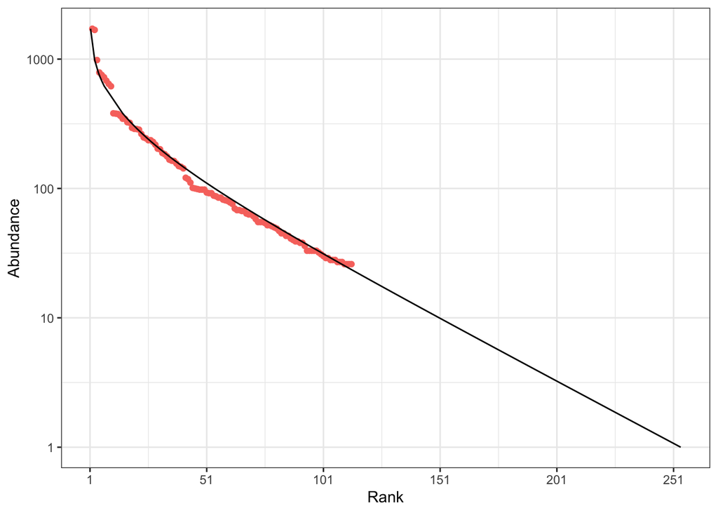

```r
# Theoretical rank of abundances
lseries_RAC <- function(abd, alpha) {
  rank <- vapply(
    abd,
    function(x) {
      n <- x * log(1 + alpha / sum(abd))
      f <- stats::integrate(function(t) {exp(-t) / t}, lower = n, upper = Inf)
      fv <- f[["value"]]
      return(alpha * fv)
    },
    FUN.VALUE = 0
  )
  tibble(rank, abundance = abd) |>
    arrange(rank)
}
# Fit alpha by minimizing the departure of species ranks from their theoretical value in a logseries
fit_alpha <- function(abd) {
  abd_decr <- sort(abd[abd > 0], decreasing = TRUE)
  optimized <- optim(
    par = vegan::fisher.alpha(abd),
    fn = function(alpha) {
      sum(abs(seq_along(abd_decr) - lseries_RAC(abd_decr, alpha)$rank))
    },
    method = "L-BFGS-B",
    lower = 0
  )
  optimized$par
}

BCI_50ha %>%
  sort(decreasing = TRUE) %>%
  subset(. > median(.)) ->
  BCI_abundant
BCI_theta <- fit_alpha(BCI_abundant)
library("divent")
BCI_abundant %>%
  as_abundances() %>%
  autoplot() +
  geom_line(
    data = lseries_RAC(BCI_50ha, alpha = BCI_theta),
    aes(x = rank, y = abundance)
  )
```

The estimate using Hubbell’s method is 45.

# Appendix 3: Full simulation

The objective is to close the loop: using the parameters obtained from the BCI data, simulate a metacommunity and then a community of the same size as BCI. To validate the approach, the simulated distribution should be similar to the actual one.

Estimation of BCI parameters $\theta$ and $m$ following Etienne (2005) with the untb package.

```r
library("untb")
if (file.exists("data/BCI_logkda.RData")) {
  # Use the saved result if available to save computation resources
  load("data/BCI_logkda.RData")
} else {
  BCI_50ha %>%
  # name conflict with dplyr::count()
  untb::count() %>%
  # requires pari/gp installed and in the path, or use gp_binary argument
  logkda() ->
  BCI_logkda
  # Save the result
  save(BCI_logkda, file = "data/BCI_logkda.RData")
}
BCI_50ha %>%
  # name conflict with dplyr::count()
  untb::count() %>%
  # Estimate theta and m
  optimal.params(log.kda = BCI_logkda) %>%
  print() ->
  BCI_params
```

```
     theta          m
47.6001882  0.0926531
```

Simulation of a metacommunity: $J_m = 10^6$ (arbitrary), $\theta$ derived from BCI data.

```r
J_m <- 1E6
theta <- BCI_params[1]
library("divent")
the_metacommunity <- rcommunity(
  1,
  size = J_m ,
  distribution = "lseries",
  fisher_alpha = theta
)
```

Distribution of the local community: $J$ from BCI and $m$ estimated previously.

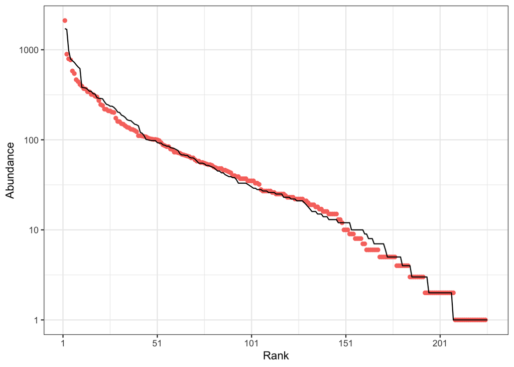

```r
J <- sum(BCI)
m <- BCI_params[2]
library("sads")
# Number of species in the local community
Svolkov(theta, m, J) %>%
  # Must be integers for the simulation
  round() %>%
  # Draw the species abundances
  rvolkov(theta, m, J) %>%
  # Make it an abundances object top plot it
  as_abundances() %>%
  # Whittaker plot
  autoplot() +
  # BCI real distribution
  geom_line(
    data = tibble(abundance = sort(BCI_50ha, decreasing = TRUE)) %>%
      mutate(rank = seq_len(n())),
    aes(x = rank, y = abundance)
  )
```

The simulated community (red dots) corresponds fairly well to the actual distribution of BCI (black line).

## References

Etienne, Rampal S. 2005. “A New Sampling Formula for Neutral Biodiversity.” *Ecology Letters* 8 (3): 253–60. https://doi.org/10.1111/j.1461-0248.2004.00717.x.

Hubbell, Stephen P. 2001. *The Unified Neutral Theory of Biodiversity and Biogeography*. Princeton University Press.